# EasyVisa_Submission

EasyVisa

Problem Statement

### Context

Business communities in the United States are facing high demand for human resources, but one of the constant challenges is identifying and attracting the right talent, which is perhaps the most important element in remaining competitive. Companies in the United States look for hard-working, talented, and qualified individuals both locally as well as abroad.

The Immigration and Nationality Act (INA) of the US permits foreign workers to come to the United States to work on either a temporary or permanent basis. The act also protects US workers against adverse impacts on their wages or working conditions by ensuring US employers' compliance with statutory requirements when they hire foreign workers to fill workforce shortages. The immigration programs are administered by the Office of Foreign Labor Certification (OFLC).

OFLC processes job certification applications for employers seeking to bring foreign workers into the United States and grants certifications in those cases where employers can demonstrate that there are not sufficient US workers available to perform the work at wages that meet or exceed the wage paid for the occupation in the area of intended employment.

### Objective

In FY 2016, the OFLC processed 775,979 employer applications for 1,699,957 positions for temporary and permanent labor certifications. This was a nine percent increase in the overall number of processed applications from the previous year. The process of reviewing every case is becoming a tedious task as the number of applicants is increasing every year.

The increasing number of applicants every year calls for a Machine Learning based solution that can help in shortlisting the candidates having higher chances of VISA approval. OFLC has hired your firm EasyVisa for data-driven solutions. You as a data scientist have to analyze the data provided and, with the help of a classification model:

- Facilitate the process of visa approvals.
- Recommend a suitable profile for the applicants for whom the visa should be certified or denied based on the drivers that significantly influence the case status.

Data Dictionary

- **case_id**: ID of each visa application
- **continent**: Continent of the employee
- **education_of_employee**: Education level of the employee
- **has_job_experience**: Does the employee have job experience? (`Y` = Yes, `N` = No)
- **requires_job_training**: Does the employee require job training? (`Y` = Yes, `N` = No)
- **no_of_employees**: Number of employees in the employer's company
- **yr_of_estab**: Year the employer's company was established
- **region_of_employment**: Intended region of employment in the US for the foreign worker
- **prevailing_wage**: Average wage paid to similarly employed workers in the area of intended employment. Ensures foreign workers are not underpaid.
- **unit_of_wage**: Unit of the prevailing wage (`Hourly`, `Weekly`, `Monthly`, or `Yearly`)
- **full_time_position**: Is the work position full-time? (`Y` = Full-Time, `N` = Part-Time)
- **case_status**: Visa application status (`Certified` or `Denied`)

Import Libraries

```python
pip install xgboost
```

```python
pip install scikit-learn==1.2.2 imbalanced-learn==0.10.1
```

```python
# -------------------------------
# ESSENTIAL LIBRARIES
# -------------------------------

# Suppress warnings
import warnings
warnings.filterwarnings("ignore")

# Data manipulation
import pandas as pd
import numpy as np

# Data visualization
import matplotlib.pyplot as plt
import seaborn as sns

# Display settings
pd.set_option("display.max_columns", None)
pd.set_option("display.max_rows", 100)
pd.set_option("display.float_format", lambda x: "%.3f" % x)

# -------------------------------
# MODEL BUILDING & EVALUATION
# -------------------------------

# Model evaluation metrics
from sklearn import metrics
from sklearn.metrics import (
    confusion_matrix,
    accuracy_score,
    precision_score,
    recall_score,
    f1_score,
    roc_auc_score,
    ConfusionMatrixDisplay,
)

# Model selection and splitting
from sklearn.model_selection import (
    train_test_split,
    StratifiedKFold,
    cross_val_score,
    GridSearchCV,
    RandomizedSearchCV,
)

# Preprocessing
from sklearn.preprocessing import StandardScaler, MinMaxScaler, OneHotEncoder
from sklearn.impute import SimpleImputer

# Classification models
from sklearn.tree import DecisionTreeClassifier
from sklearn.linear_model import LogisticRegression
from sklearn.ensemble import (
    RandomForestClassifier,
    BaggingClassifier,
    AdaBoostClassifier,
    GradientBoostingClassifier,
    StackingClassifier,
)

# XGBoost
from xgboost import XGBClassifier

# Sampling techniques
from imblearn.over_sampling import SMOTE
from imblearn.under_sampling import RandomUnderSampler
```

Reading input File

```python
visa_df = pd.read_csv("EasyVisa.csv")
```

```python
visa_df.head()
```

|  | case_id | continent | education_of_employee | has_job_experience | requires_job_training | no_of_employees | yr_of_estab | region_of_employment | prevailing_wage | unit_of_wage | full_time_position | case_status |
| --- | --- | --- | --- | --- | --- | --- | --- | --- | --- | --- | --- | --- |
| 0 | EZYV01 | Asia | High School | N | N | 14513 | 2007 | West | 592.203 | Hour | Y | Denied |
| 1 | EZYV02 | Asia | Master's | Y | N | 2412 | 2002 | Northeast | 83425.650 | Year | Y | Certified |
| 2 | EZYV03 | Asia | Bachelor's | N | Y | 44444 | 2008 | West | 122996.860 | Year | Y | Denied |
| 3 | EZYV04 | Asia | Bachelor's | N | N | 98 | 1897 | West | 83434.030 | Year | Y | Denied |
| 4 | EZYV05 | Africa | Master's | Y | N | 1082 | 2005 | South | 149907.390 | Year | Y | Certified |

```python
data = visa_df.copy()
```

Data Overview

```python
# Looking at the first 5 rows
visa_df.head()
```

|  | case_id | continent | education_of_employee | has_job_experience | requires_job_training | no_of_employees | yr_of_estab | region_of_employment | prevailing_wage | unit_of_wage | full_time_position | case_status |
| --- | --- | --- | --- | --- | --- | --- | --- | --- | --- | --- | --- | --- |
| 0 | EZYV01 | Asia | High School | N | N | 14513 | 2007 | West | 592.203 | Hour | Y | Denied |
| 1 | EZYV02 | Asia | Master's | Y | N | 2412 | 2002 | Northeast | 83425.650 | Year | Y | Certified |
| 2 | EZYV03 | Asia | Bachelor's | N | Y | 44444 | 2008 | West | 122996.860 | Year | Y | Denied |
| 3 | EZYV04 | Asia | Bachelor's | N | N | 98 | 1897 | West | 83434.030 | Year | Y | Denied |
| 4 | EZYV05 | Africa | Master's | Y | N | 1082 | 2005 | South | 149907.390 | Year | Y | Certified |

```python
# Looking at the last 5 rows
visa_df.tail()
```

|  | case_id | continent | education_of_employee | has_job_experience | requires_job_training | no_of_employees | yr_of_estab | region_of_employment | prevailing_wage | unit_of_wage | full_time_position | case_status |
| --- | --- | --- | --- | --- | --- | --- | --- | --- | --- | --- | --- | --- |
| 25475 | EZYV25476 | Asia | Bachelor's | Y | Y | 2601 | 2008 | South | 77092.570 | Year | Y | Certified |
| 25476 | EZYV25477 | Asia | High School | Y | N | 3274 | 2006 | Northeast | 279174.790 | Year | Y | Certified |
| 25477 | EZYV25478 | Asia | Master's | Y | N | 1121 | 1910 | South | 146298.850 | Year | N | Certified |
| 25478 | EZYV25479 | Asia | Master's | Y | Y | 1918 | 1887 | West | 86154.770 | Year | Y | Certified |
| 25479 | EZYV25480 | Asia | Bachelor's | Y | N | 3195 | 1960 | Midwest | 70876.910 | Year | Y | Certified |

```python
# Looking at the statistical summary of all variables
visa_df.describe(include='all').T
```

|  | count | unique | top | freq | mean | std | min | 25% | 50% | 75% | max |
| --- | --- | --- | --- | --- | --- | --- | --- | --- | --- | --- | --- |
| case_id | 25480 | 25480 | EZYV01 | 1 | NaN | NaN | NaN | NaN | NaN | NaN | NaN |
| continent | 25480 | 6 | Asia | 16861 | NaN | NaN | NaN | NaN | NaN | NaN | NaN |
| education_of_employee | 25480 | 4 | Bachelor's | 10234 | NaN | NaN | NaN | NaN | NaN | NaN | NaN |
| has_job_experience | 25480 | 2 | Y | 14802 | NaN | NaN | NaN | NaN | NaN | NaN | NaN |
| requires_job_training | 25480 | 2 | N | 22525 | NaN | NaN | NaN | NaN | NaN | NaN | NaN |
| no_of_employees | 25480.000 | NaN | NaN | NaN | 5667.043 | 22877.929 | -26.000 | 1022.000 | 2109.000 | 3504.000 | 602069.000 |
| yr_of_estab | 25480.000 | NaN | NaN | NaN | 1979.410 | 42.367 | 1800.000 | 1976.000 | 1997.000 | 2005.000 | 2016.000 |
| region_of_employment | 25480 | 5 | Northeast | 7195 | NaN | NaN | NaN | NaN | NaN | NaN | NaN |
| prevailing_wage | 25480.000 | NaN | NaN | NaN | 74455.815 | 52815.942 | 2.137 | 34015.480 | 70308.210 | 107735.513 | 319210.270 |
| unit_of_wage | 25480 | 4 | Year | 22962 | NaN | NaN | NaN | NaN | NaN | NaN | NaN |
| full_time_position | 25480 | 2 | Y | 22773 | NaN | NaN | NaN | NaN | NaN | NaN | NaN |
| case_status | 25480 | 2 | Certified | 17018 | NaN | NaN | NaN | NaN | NaN | NaN | NaN |

```python
visa_df.shape
```

```
(25480, 12)
```

```python
# Checking the data types
visa_df.info()
```

```
<class 'pandas.core.frame.DataFrame'>
RangeIndex: 25480 entries, 0 to 25479
Data columns (total 12 columns):
 #   Column                 Non-Null Count  Dtype
---  ------                 --------------  -----
 0   case_id                25480 non-null  object
 1   continent              25480 non-null  object
 2   education_of_employee  25480 non-null  object
 3   has_job_experience     25480 non-null  object
 4   requires_job_training  25480 non-null  object
 5   no_of_employees        25480 non-null  int64
 6   yr_of_estab            25480 non-null  int64
 7   region_of_employment   25480 non-null  object
 8   prevailing_wage        25480 non-null  float64
 9   unit_of_wage           25480 non-null  object
 10  full_time_position     25480 non-null  object
 11  case_status            25480 non-null  object
dtypes: float64(1), int64(2), object(9)
memory usage: 2.3+ MB
```

```python
# Checking for missing values
visa_df.isnull().sum()
```

```
case_id                  0
continent                0
education_of_employee    0
has_job_experience       0
requires_job_training    0
no_of_employees          0
yr_of_estab              0
region_of_employment     0
prevailing_wage          0
unit_of_wage             0
full_time_position       0
case_status              0
dtype: int64
```

```python
# Checking for duplicated values
visa_df.duplicated().sum()
```

```
0
```

Exploratory Data Analysis (Univariate EDA)

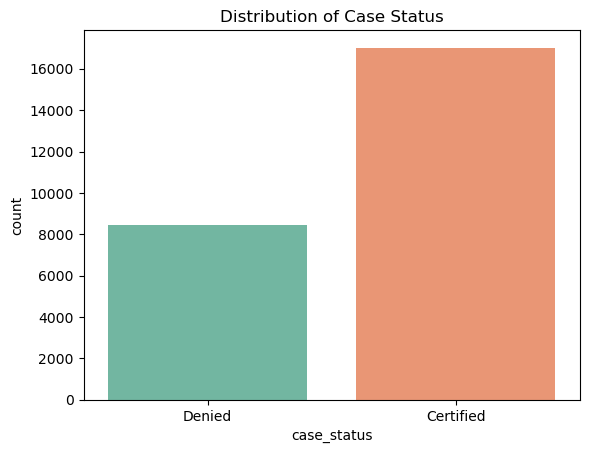

```python
# 1. Target variable - case_status
sns.countplot(x='case_status', data=visa_df, palette='Set2')
plt.title('Distribution of Case Status')
plt.show()
```

**Observation**: Most applications are 'Certified', with fewer 'Denied' or other statuses.  
**Inference**: The data is imbalanced and will require resampling techniques like SMOTE or undersampling.

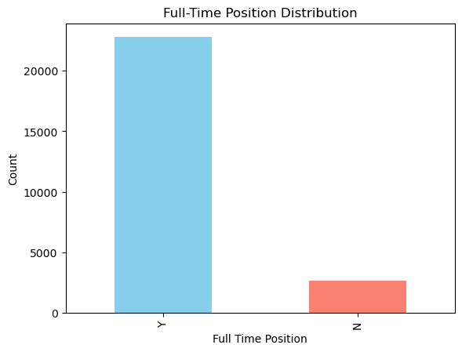

```python
# 2. full_time_position
visa_df['full_time_position'].value_counts().plot(kind='bar', color=['skyblue', 'salmon'])
plt.title("Full-Time Position Distribution")
plt.xlabel("Full Time Position")
plt.ylabel("Count")
plt.show()
```

**Observation**: Most jobs are full-time positions (Y).

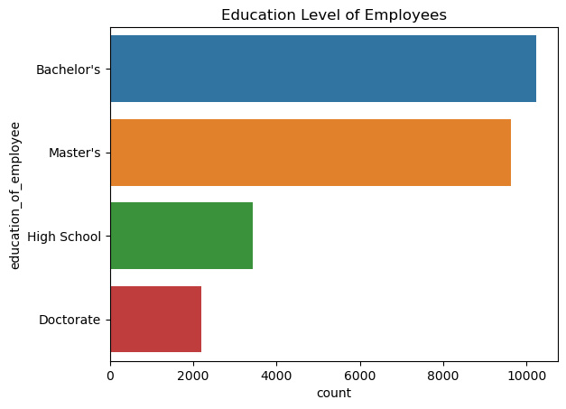

```python
# 3. education_of_employee
sns.countplot(y='education_of_employee', data=visa_df, order=visa_df['education_of_employee'].value_counts().index)
plt.title("Education Level of Employees")
plt.show()
```

**Observation**: Bachelors and Masters dominate the education levels.

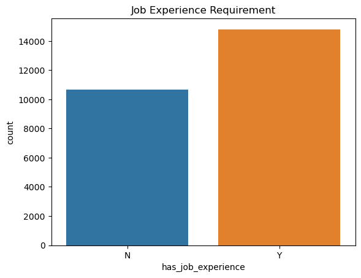

```python
# 4. has_job_experience
sns.countplot(x='has_job_experience', data=visa_df)
plt.title("Job Experience Requirement")
plt.show()
```

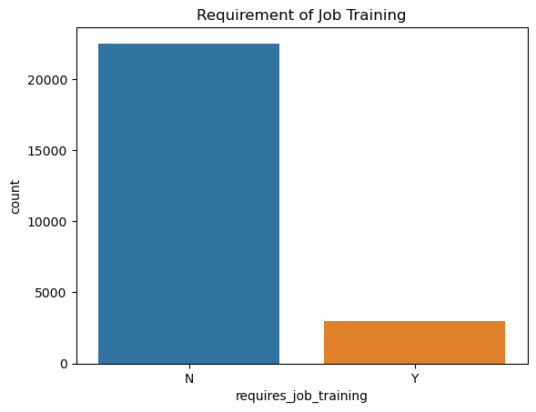

```python
# 5. requires_job_training
sns.countplot(x='requires_job_training', data=visa_df)
plt.title("Requirement of Job Training")
plt.show()
```

**Observation**: Most roles do not require job training.

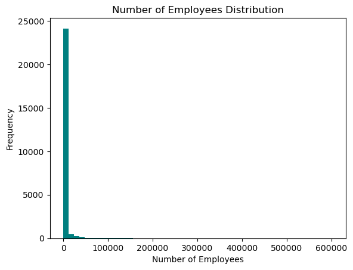

```python
# 6. no_of_employees
plt.hist(visa_df['no_of_employees'], bins=50, color='teal')
plt.title("Number of Employees Distribution")
plt.xlabel("Number of Employees")
plt.ylabel("Frequency")
plt.show()
```

**Observation**: Right-skewed. Many companies have small sizes, a few are large.

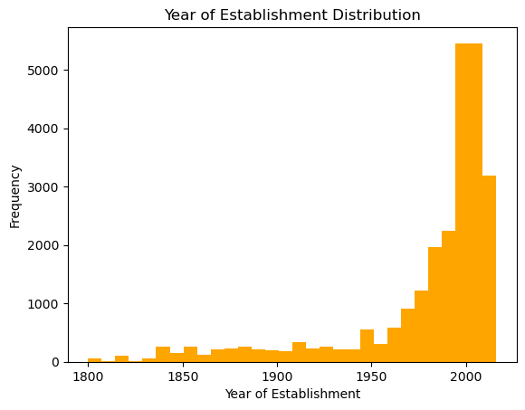

```python
# 7. yr_of_estab
plt.hist(visa_df['yr_of_estab'], bins=30, color='orange')
plt.title("Year of Establishment Distribution")
plt.xlabel("Year of Establishment")
plt.ylabel("Frequency")
plt.show()
```

**Observation**: More companies were established post-1990s.

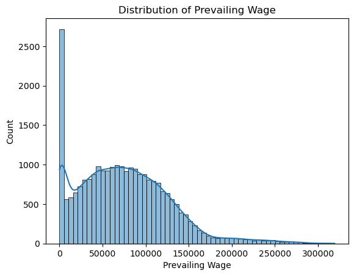

```python
# 8. prevailing_wage
sns.histplot(visa_df['prevailing_wage'], bins=60, kde=True)
plt.title("Distribution of Prevailing Wage")
plt.xlabel("Prevailing Wage")
plt.show()
```

**Observation**: Right-skewed. Most wages fall below 150K.

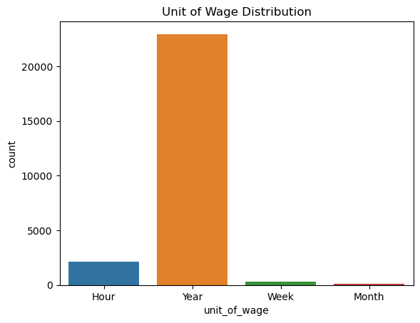

```python
# 9. unit_of_wage
sns.countplot(x='unit_of_wage', data=visa_df)
plt.title("Unit of Wage Distribution")
plt.show()
```

**Observation**: Most wages are reported annually.

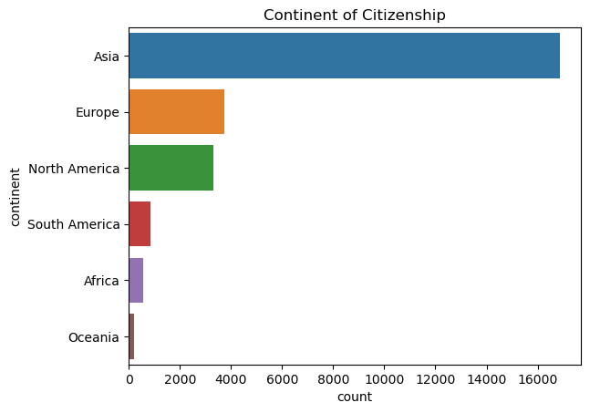

```python
# 10. continent
sns.countplot(y='continent', data=visa_df, order=visa_df['continent'].value_counts().index)
plt.title("Continent of Citizenship")
plt.show()
```

**Observation**:

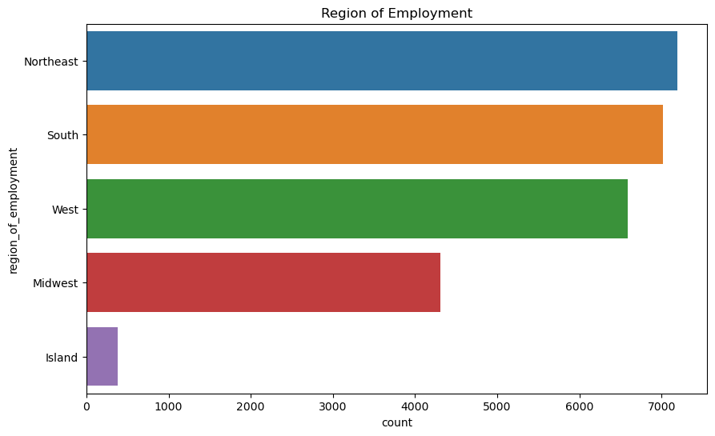

```python
# 11. region_of_employment
plt.figure(figsize=(10, 6))
sns.countplot(y='region_of_employment', data=visa_df, order=visa_df['region_of_employment'].value_counts().index)
plt.title("Region of Employment")
plt.show()
```

**Observation**:

Exploratory Data Analysis (Bivariate EDA)

```python
# Function to plot stacked bar chart for categories

def stacked_barplot(data, predictor, target):
    """
    Print the category counts and plot a stacked bar chart

    data: dataframe
    predictor: independent variable
    target: target variable
    """
    count = data[predictor].nunique()
    sorter = data[target].value_counts().index[-1]
    tab1 = pd.crosstab(data[predictor], data[target], margins=True).sort_values(
        by=sorter, ascending=False
    )
    print(tab1)
    print("-" * 120)
    tab = pd.crosstab(data[predictor], data[target], normalize="index").sort_values(
        by=sorter, ascending=False
    )
    tab.plot(kind="bar", stacked=True, figsize=(count + 5, 5))
    plt.legend(
        loc="lower left", frameon=False,
    )
    plt.legend(loc="upper left", bbox_to_anchor=(1, 1))
    plt.show()
```

```python
# Function to plot distributions wrt target

def distribution_plot_wrt_target(data, predictor, target):

    fig, axs = plt.subplots(2, 2, figsize=(12, 10))

    target_uniq = data[target].unique()

    axs[0, 0].set_title("Distribution of target for target=" + str(target_uniq[0]))
    sns.histplot(
        data=data[data[target] == target_uniq[0]],
        x=predictor,
        kde=True,
        ax=axs[0, 0],
        color="teal",
        stat="density",
    )

    axs[0, 1].set_title("Distribution of target for target=" + str(target_uniq[1]))
    sns.histplot(
        data=data[data[target] == target_uniq[1]],
        x=predictor,
        kde=True,
        ax=axs[0, 1],
        color="orange",
        stat="density",
    )

    axs[1, 0].set_title("Boxplot w.r.t target")
    sns.boxplot(data=data, x=target, y=predictor, ax=axs[1, 0], palette="gist_rainbow")

    axs[1, 1].set_title("Boxplot (without outliers) w.r.t target")
    sns.boxplot(
        data=data,
        x=target,
        y=predictor,
        ax=axs[1, 1],
        showfliers=False,
        palette="gist_rainbow",
    )

    plt.tight_layout()
    plt.show()
```

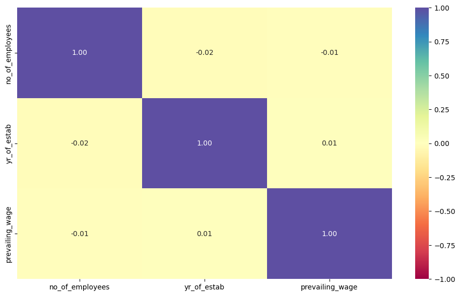

```python
# Creating a new variable with numerical columns
cols_list = visa_df.select_dtypes(include=np.number).columns.tolist()

# Visualizing a correlation map
plt.figure(figsize=(12, 7))
sns.heatmap(visa_df[cols_list].corr(), annot=True, vmin=-1, vmax=1, fmt=".2f", cmap="Spectral");
```

**Observations**:

- There doesn't seem to be any significant correlation between numerical variables.

```
case_status            Certified  Denied    All
education_of_employee
All                        17018    8462  25480
Bachelor's                  6367    3867  10234
High School                 1164    2256   3420
Master's                    7575    2059   9634
Doctorate                   1912     280   2192
------------------------------------------------------------------------------------------------------------------------
```

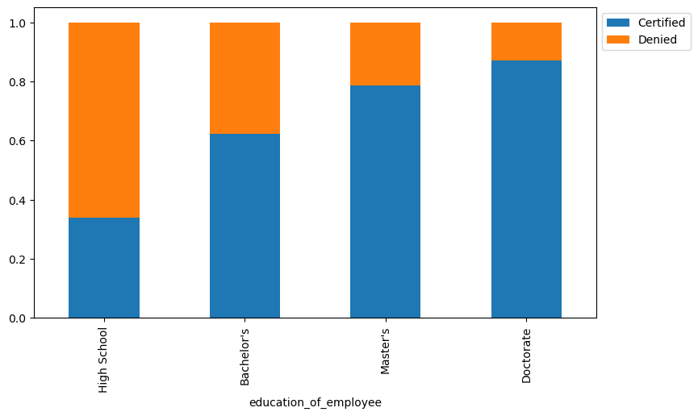

```python
# Relation between education and case status
stacked_barplot(visa_df, 'education_of_employee', 'case_status')
```

**Observations**:

```
case_status    Certified  Denied    All
continent
All                17018    8462  25480
Asia               11012    5849  16861
North America       2037    1255   3292
Europe              2957     775   3732
South America        493     359    852
Africa               397     154    551
Oceania              122      70    192
------------------------------------------------------------------------------------------------------------------------
```

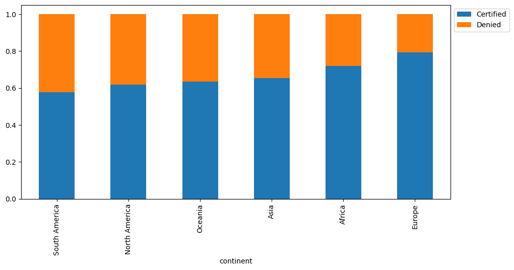

```python
# Relation between continent and case status
stacked_barplot(visa_df, 'continent', 'case_status')
```

**Observations**:

- South America has the lowest approval rate with a little below 60%.
- Europe has the highest approval rate with ~80% of the visas being certified.

```
case_status           Certified  Denied    All
region_of_employment
All                       17018    8462  25480
Northeast                  4526    2669   7195
West                       4100    2486   6586
South                      4913    2104   7017
Midwest                    3253    1054   4307
Island                      226     149    375
------------------------------------------------------------------------------------------------------------------------
```

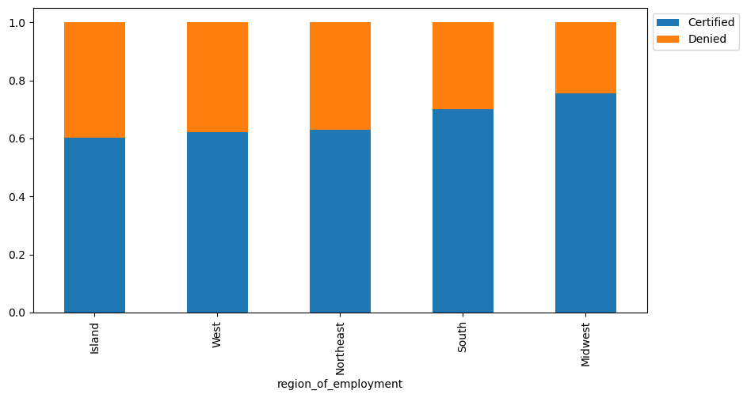

```python
stacked_barplot(visa_df, 'region_of_employment', 'case_status')
```

**Observations**:

- Midwest and Island are the regions with the least amount of visa requests. However the approval percentage is very different for these regions.
- There isn't a relation between the amount of workers intended region of employment and case status.
- Midwest and South have the highest certified rates at around 75%.
- Island and West have a 60% approval rate.

```
education_of_employee  Bachelor's  Doctorate  High School  Master's    All
region_of_employment
All                         10234       2192         3420      9634  25480
West                         2925        714          785      2162   6586
Northeast                    2874        656          905      2760   7195
South                        2991        541          934      2551   7017
Midwest                      1315        256          736      2000   4307
Island                        129         25           60       161    375
------------------------------------------------------------------------------------------------------------------------
```

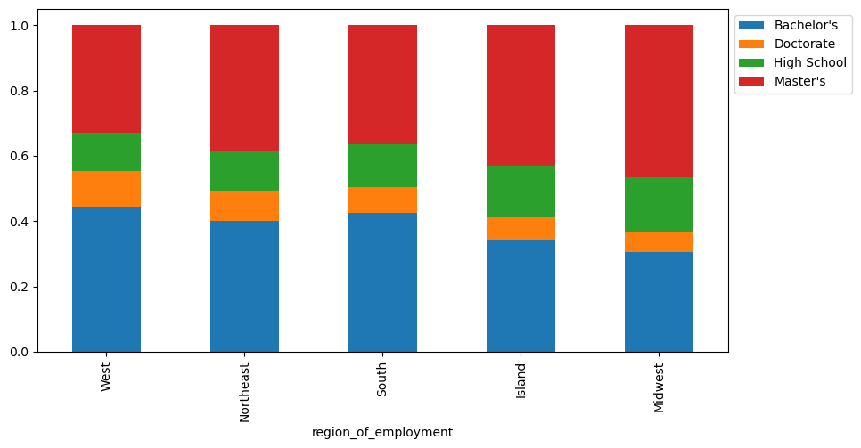

```python
# Visual on region and education level
stacked_barplot(visa_df, 'region_of_employment', 'education_of_employee')
```

**Observations**:

- Workers with the highest level of education (doctorate) request more employment in the West and Northeast.
- Most of workers with a masters request Island or Midwest. The regions with least amounts of requests.
- However, Island and Midwest also have more request of workers that only have a High School degree.
- South and West have more workers with a Bachelors.

```
case_status         Certified  Denied    All
has_job_experience
All                     17018    8462  25480
N                        5994    4684  10678
Y                       11024    3778  14802
------------------------------------------------------------------------------------------------------------------------
```

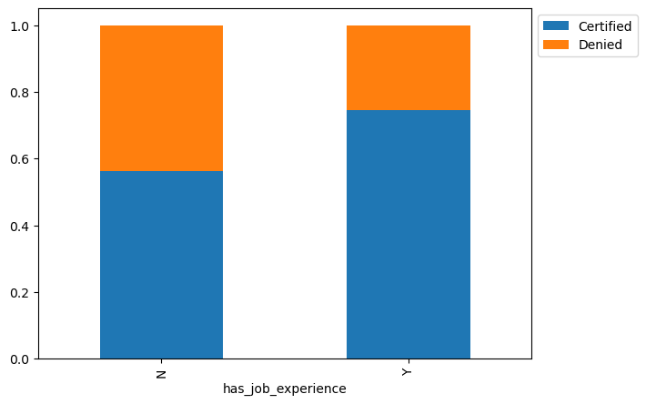

```python
# Relation between job experience and case status
stacked_barplot(visa_df, 'has_job_experience', 'case_status')
```

**Observations**:

- There is ~20% increase in certified visas for workers with job experience.

```
case_status   Certified  Denied    All
unit_of_wage
All               17018    8462  25480
Year              16047    6915  22962
Hour                747    1410   2157
Week                169     103    272
Month                55      34     89
------------------------------------------------------------------------------------------------------------------------
```

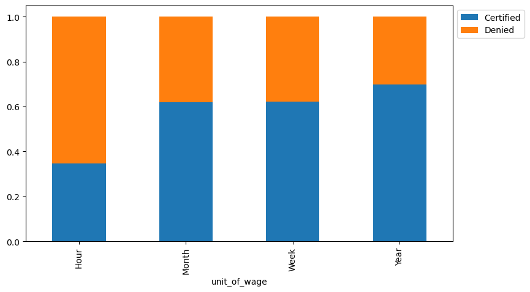

```python
# Relation between unit of wage and case status
stacked_barplot(visa_df, 'unit_of_wage', 'case_status')
```

**Observations**:

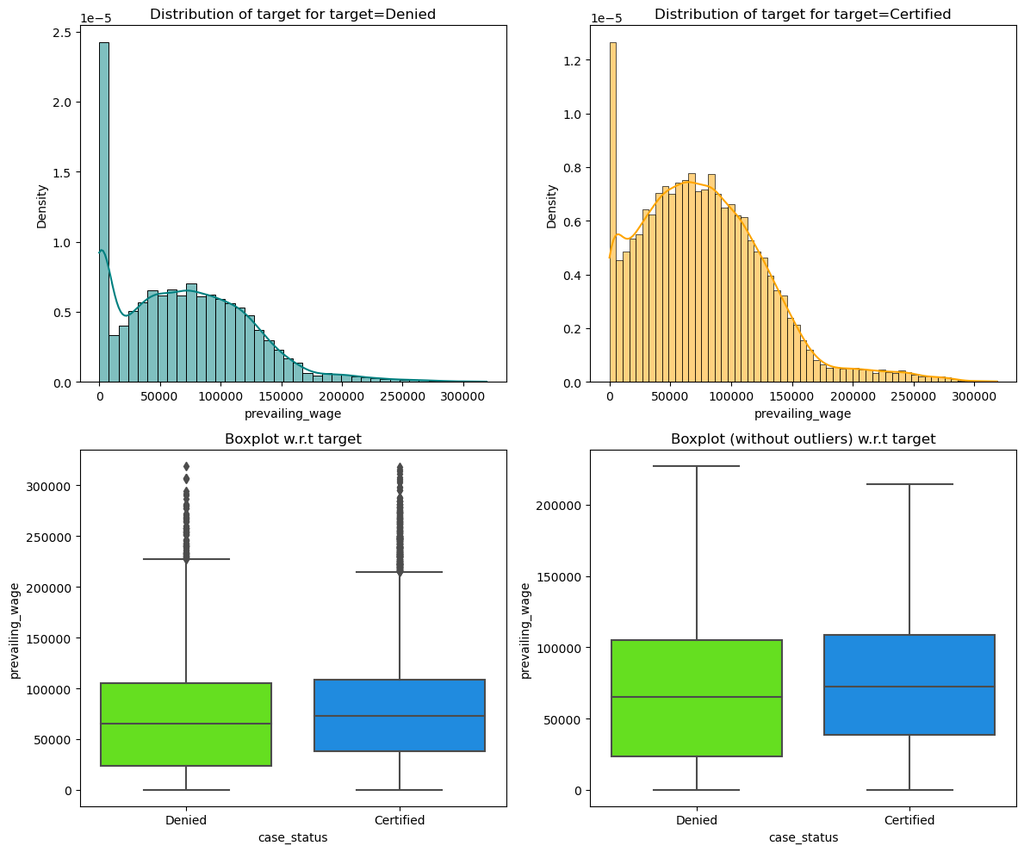

```python
# Relation between prevailing wage and case status
distribution_plot_wrt_target(visa_df, 'prevailing_wage', 'case_status')
```

**Observations**:

- There isn't much difference between certified and denied case status in relation to prevailing wage.
- Denied cases have a slightly lower median than certified.

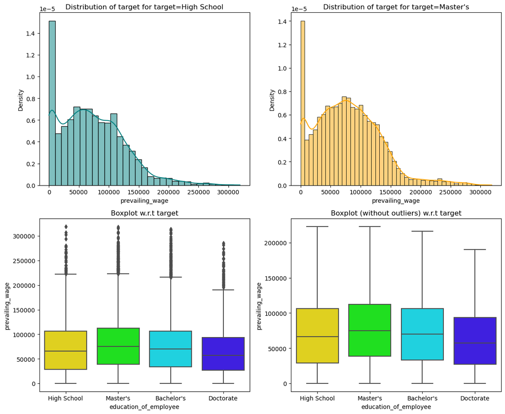

```python
# Relation between prevailing wage and education level
distribution_plot_wrt_target(visa_df, 'prevailing_wage', 'education_of_employee')
```

**Observations**:

- It is surprising that workers with a doctorate have a lower median than those with a High School degree. We will check if this is due to work experience or required job training.
- Master's and Bachelor's workers have a very similar prevailing wage.
- Workers with a High School degree have a slightly lower prevailing wage than Master's and Bachelor's.
- These dataset doesn't include certification and especialized jobs. This could influence prevailing wage for workers with a High School degree.

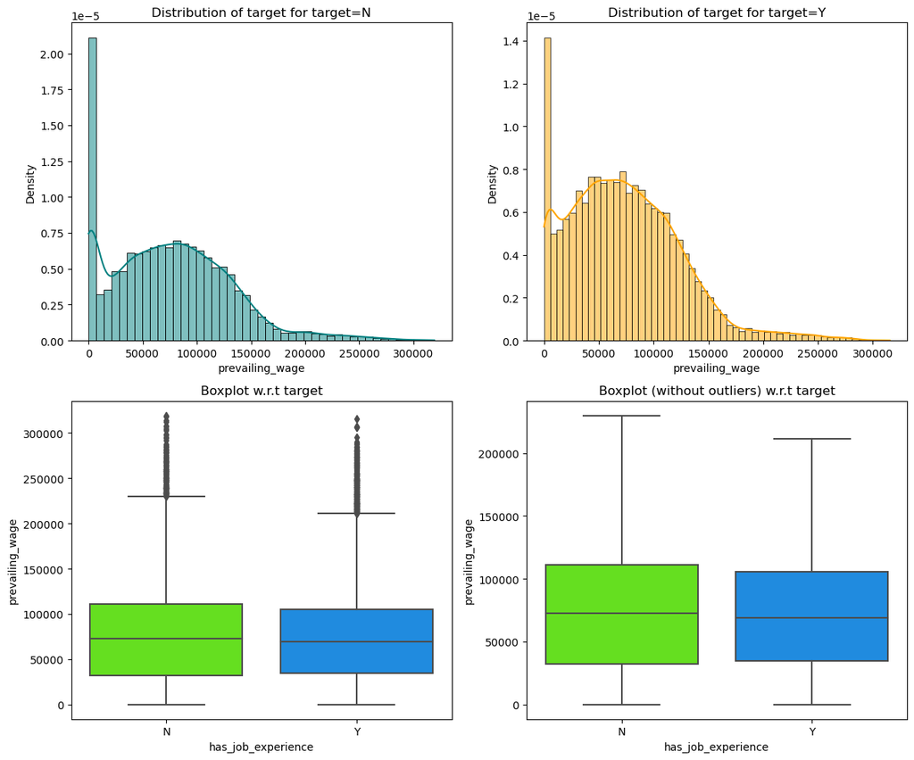

```python
# Visuals on prevailing wage and job experience
distribution_plot_wrt_target(visa_df, 'prevailing_wage', 'has_job_experience')
```

**Observations**:

- There seems to be a higher prevailing wage for workers with no work experience.
- We will check if this is also related with education level. Usually people with higher education have less work experience due to dedicating their time to education.

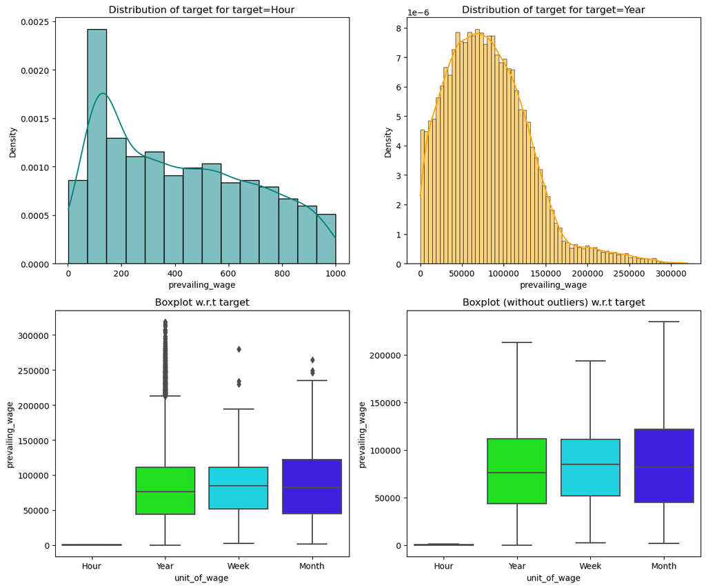

```python
# Relation between prevailing and unit of wage
distribution_plot_wrt_target(visa_df,'prevailing_wage', 'unit_of_wage')
```

**Observations**:

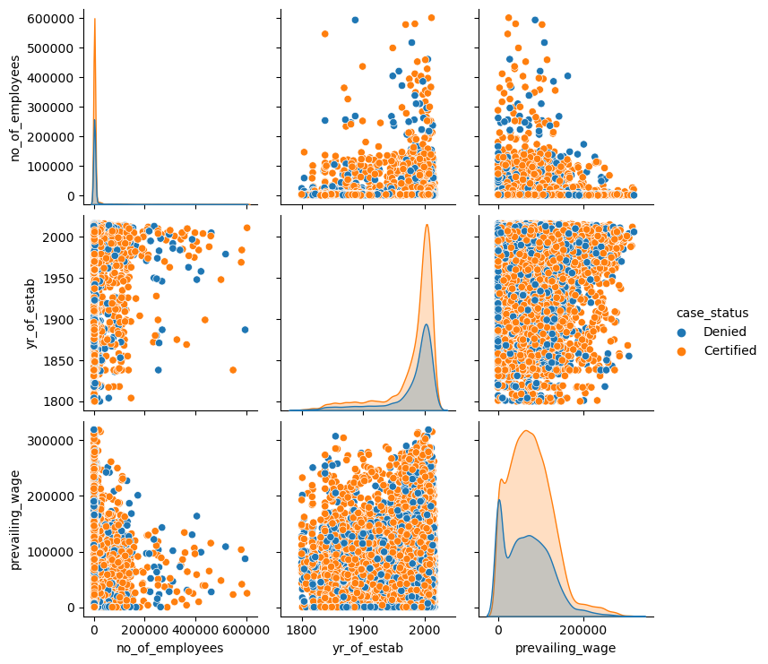

```python
sns.pairplot(visa_df, hue='case_status')
```

**Observations**:

- The pair plot suggests that Case Status is influenced by prevailing wages, year of establishment and number of employees, as indicated by the patterns observed in the diagnoal KDE plots.

Data Preparation for modeling

```python
visa_df["case_status"] = visa_df["case_status"].apply(lambda x: 1 if x == "Certified" else 0) #converting case status values into binary values

X = visa_df.drop(["case_status"], axis=1) # preparing independent variables
y = visa_df["case_status"]# preparing target variable
```

```python
X = pd.get_dummies(X, drop_first=True) # using one-hot encoding to encode categorical features
```

```python
# Splitting data into training and validation set:
X_train, X_val, y_train, y_val = train_test_split(
    X, y, test_size=0.30, random_state=1, stratify=y
)

#Test data
X_val,X_test,y_val,y_test = train_test_split(
    X_val,y_val,test_size=0.1,random_state=1,stratify=y_val
)
```

```python
print("Number of rows in train data =", X_train.shape[0]) #Training set is used to train the model in the first place.
print("Number of rows in validation data =", X_val.shape[0]) #Validation set is used for fine-tuning model parameters
print("Number of rows in test data =", X_test.shape[0]) #Test set is used for evaluating the final model performance on unseen data.
```

```
Number of rows in train data = 17836
Number of rows in validation data = 6879
Number of rows in test data = 765
```

Model Building

### Model Evaluation Criterion

#### Possible wrong predictions that can be made by the model

- **False Positive:** The model predicts that the applicant will get certified, while in reality the applicant does not have the necessary qualifications to be certified.
- **False Negative:** The model predicts that the applicant should not get certified, while in reality the applicant has all qualifications to be certified.

#### Which scenario is more important?

- **Reducing false positives** is important because if an unqualified candidate receives certification, it means that a qualified US worker will lose an opportunity for employment.
- **Reducing false negatives** is also important because if a qualified candidate is denied the opportunity for employment, the company will lose a suitable candidate for the role.

#### Best metric to be considered

**F1 Score** should be prioritized as we want a balanced evaluation of both errors, because both false positives and false negatives have similar business consequences.

F1 Score is ideal for this situation because a high F1 Score indicates that the model is making correct classifications with a balance between **Precision** and **Recall**.

```python
# defining a function to compute different metrics to check performance of a classification model built using sklearn


def model_performance_classification_sklearn(model, predictors, target):
    """
    Function to compute different metrics to check classification model performance

    model: classifier
    predictors: independent variables
    target: dependent variable
    """

    # predicting using the independent variables
    pred = model.predict(predictors)

    acc = accuracy_score(target, pred)  # to compute Accuracy
    recall = recall_score(target, pred)  # to compute Recall
    precision = precision_score(target, pred)  # to compute Precision
    f1 = f1_score(target, pred)  # to compute F1-score

    # creating a dataframe of metrics
    df_perf = pd.DataFrame(
        {"Accuracy": acc, "Recall": recall, "Precision": precision, "F1": f1,},
        index=[0],
    )

    return df_perf
```

```python
def confusion_matrix_sklearn(model, predictors, target):
    """
    To plot the confusion_matrix with percentages

    model: classifier
    predictors: independent variables
    target: dependent variable
    """
    y_pred = model.predict(predictors)
    cm = confusion_matrix(target, y_pred)
    labels = np.asarray(
        [
            ["{0:0.0f}".format(item) + "\n{0:.2%}".format(item / cm.flatten().sum())]
            for item in cm.flatten()
        ]
    ).reshape(2, 2)

    plt.figure(figsize=(6, 4))
    sns.heatmap(cm, annot=labels, fmt="")
    plt.ylabel("True label")
    plt.xlabel("Predicted label")
```

```python
scorer = metrics.make_scorer(metrics.f1_score)
#Creates a custom scorer using the F1 score to evaluate model performance
```

Model building with original data

```python
models = []  # Empty list to store all the models

models.append(("Bagging", BaggingClassifier(random_state=1)))# adding bagging model to list
models.append(("Random forest", RandomForestClassifier(random_state=1)))# adding random forest model to list
```

```python
models.append(("GBM", GradientBoostingClassifier(random_state=1)))# adding gradient boosting model to list
```

```python
models.append(("Adaboost", AdaBoostClassifier(random_state=1)))# adding adaboost model
```

```python
models.append(("Xgboost", XGBClassifier(random_state=1, eval_metric="logloss")))# adding xgboost model
```

```python
models.append(("dtree", DecisionTreeClassifier(random_state=1))) #adding decision tree classifier model
```

```python
results1 = []  # Empty list to store all cross-validation scores
names = []  # Empty list to store name of the models


# loop through all models to get the mean cross validated score on training dataset
print("\n" "Cross-Validation performance on training dataset with original data:" "\n")

for name, model in models:
    kfold = StratifiedKFold(
        n_splits=2, shuffle=True, random_state=1 # defining 2 fold stratified cross-validation
    )
    cv_result = cross_val_score(
        estimator=model, X=X_train, y=y_train, scoring = scorer,cv=kfold
    ) #perform cross-validation and get F1 score
    results1.append(cv_result)# append result to list
    names.append(name)
    print("{}: {}".format(name, cv_result.mean()))

print("\n" "Validation Performance:" "\n")

#loop through each model to train and evaluate it on validation dataset
for name, model in models:
    model.fit(X_train, y_train)#train model on training data
    scores = f1_score(y_val, model.predict(X_val)) #calculate F1 score on validation data
    print("{}: {}".format(name, scores)) #print F1 score for each model
```

[output not shown]

[figure not shown]

```python
# Plotting boxplots for CV scores of all models defined above
fig = plt.figure(figsize=(10, 7))

fig.suptitle("Algorithm Comparison")
ax = fig.add_subplot(111)

plt.boxplot(results1)
ax.set_xticklabels(names)

plt.show()
```

**Observation**:

Model Building with oversampled data

```python
print("Before OverSampling, counts of label '1': {}".format(sum(y_train == 1)))
print("Before OverSampling, counts of label '0': {} \n".format(sum(y_train == 0)))

# Synthetic Minority Over Sampling Technique
sm = SMOTE(sampling_strategy=1, k_neighbors=5, random_state=1)
X_train_over, y_train_over = sm.fit_resample(X_train, y_train)


print("After OverSampling, counts of label '1': {}".format(sum(y_train_over == 1)))
print("After OverSampling, counts of label '0': {} \n".format(sum(y_train_over == 0)))


print("After OverSampling, the shape of train_X: {}".format(X_train_over.shape))
print("After OverSampling, the shape of train_y: {} \n".format(y_train_over.shape))
```

```
Before OverSampling, counts of label '1': 11913
Before OverSampling, counts of label '0': 5923

After OverSampling, counts of label '1': 11913
After OverSampling, counts of label '0': 11913

After OverSampling, the shape of train_X: (23826, 25500)
After OverSampling, the shape of train_y: (23826,)
```

```python
models = []  # Empty list to store all the models

# Appending models into the list
models.append(("Bagging", BaggingClassifier(random_state=1)))
models.append(("Random forest", RandomForestClassifier(random_state=1)))
models.append(("GBM", GradientBoostingClassifier(random_state=1)))
models.append(("Adaboost", AdaBoostClassifier(random_state=1)))
models.append(("Xgboost", XGBClassifier(random_state=1, eval_metric="logloss")))
models.append(("dtree", DecisionTreeClassifier(random_state=1)))

results1 = []  # Empty list to store all model's CV scores
names = []  # Empty list to store name of the models


# loop through all models to get the mean cross validated score
print("\n" "Cross-Validation performance on training dataset with oversampled data:" "\n")

for name, model in models:
    kfold = StratifiedKFold(
        n_splits=2, shuffle=True, random_state=1
    )  # Setting number of splits equal to 5
    cv_result = cross_val_score(
        estimator=model, X=X_train_over, y=y_train_over,scoring = scorer, cv=kfold
    )
    results1.append(cv_result)
    names.append(name)
    print("{}: {}".format(name, cv_result.mean()))

print("\n" "Validation Performance:" "\n")

for name, model in models:
    model.fit(X_train_over, y_train_over)
    scores = f1_score(y_val, model.predict(X_val))
    print("{}: {}".format(name, scores))
```

[output not shown]

[figure not shown]

```python
# Plotting boxplots for CV scores of all models defined above
fig = plt.figure(figsize=(10, 7))

fig.suptitle("Algorithm Comparison")
ax = fig.add_subplot(111)

plt.boxplot(results1)
ax.set_xticklabels(names)

plt.show()
```

**Observation**:

Model Building with undersampled data

```python
rus = RandomUnderSampler(random_state=1, sampling_strategy=1)
X_train_un, y_train_un = rus.fit_resample(X_train, y_train)


print("Before UnderSampling, counts of label '1': {}".format(sum(y_train == 1)))
print("Before UnderSampling, counts of label '0': {} \n".format(sum(y_train == 0)))


print("After UnderSampling, counts of label '1': {}".format(sum(y_train_un == 1)))
print("After UnderSampling, counts of label '0': {} \n".format(sum(y_train_un == 0)))


print("After UnderSampling, the shape of train_X: {}".format(X_train_un.shape))
print("After UnderSampling, the shape of train_y: {} \n".format(y_train_un.shape))
```

```
Before UnderSampling, counts of label '1': 11913
Before UnderSampling, counts of label '0': 5923

After UnderSampling, counts of label '1': 5923
After UnderSampling, counts of label '0': 5923

After UnderSampling, the shape of train_X: (11846, 25500)
After UnderSampling, the shape of train_y: (11846,)
```

```python
models = []  # Empty list to store all the models

# Appending models into the list
models.append(("Bagging", BaggingClassifier(random_state=1)))
models.append(("Random forest", RandomForestClassifier(random_state=1)))
models.append(("GBM", GradientBoostingClassifier(random_state=1)))
models.append(("Adaboost", AdaBoostClassifier(random_state=1)))
models.append(("Xgboost", XGBClassifier(random_state=1, eval_metric="logloss",n_jobs=-1)))
models.append(("dtree", DecisionTreeClassifier(random_state=1)))

results1 = []  # Empty list to store all model's CV scores
names = []  # Empty list to store name of the models


# loop through all models to get the mean cross validated score
print("\n" "Cross-Validation performance on training dataset with undersampled data:" "\n")

for name, model in models:
    kfold = StratifiedKFold(
        n_splits=2, shuffle=True, random_state=1
    )  # Setting number of splits equal to 2
    cv_result = cross_val_score(
        estimator=model, X=X_train_un, y=y_train_un,scoring = scorer, cv=kfold,n_jobs =-1
    )
    results1.append(cv_result)
    names.append(name)
    print("{}: {}".format(name, cv_result.mean()))

print("\n" "Validation Performance:" "\n")

for name, model in models:
    model.fit(X_train_un, y_train_un)
    scores = f1_score(y_val, model.predict(X_val))
    print("{}: {}".format(name, scores))
```

[output not shown]

[figure not shown]

```python
# Plotting boxplots for CV scores of all models defined above
fig = plt.figure(figsize=(10, 7))

fig.suptitle("Algorithm Comparison")
ax = fig.add_subplot(111)

plt.boxplot(results1)
ax.set_xticklabels(names)

plt.show()
```

**Observation**:

**The models selected for hyperparameter tuning are -**

- GBM with original data: Best overall performance with high F1 scores in both training and validation, showing strong generalization.
- Adaboost with undersampled data: Showed highest validation performance improvement, indicating it benefits significantly from undersampling.
- XGBoost with original data: Consistently stable, with near zero performance drop, making it highly reliable.
- GBM with oversampled data: Maintained strong peformance with minimal drop, proving its robustness with oversampling.

Hyperparameter Tuning

#### 1. Tuning Gradient Boost with original data

```python
%%time

# defining model
Model = GradientBoostingClassifier(random_state=1)

#Parameter grid to pass in RandomSearchCV
param_grid={"n_estimators": np.arange(100,150,25), "learning_rate": [0.2, 0.05, 1], "subsample":[0.5,0.7], "max_features":[0.5,0.7]}

#Calling RandomizedSearchCV
randomized_cv = RandomizedSearchCV(estimator=Model, param_distributions=param_grid, scoring=scorer, n_iter=50, n_jobs = -1, cv=5, random_state=1)

#Fitting parameters in RandomizedSearchCV
randomized_cv.fit(X_train, y_train)## Fit the original model

print("Best parameters are {} with CV score={}:" .format(randomized_cv.best_params_,randomized_cv.best_score_))
```

[output not shown]

```python
tuned_gbm_orig = GradientBoostingClassifier(
    n_estimators=125,
    learning_rate=0.05,
    subsample=0.7,
    max_features=0.7,
    random_state=1
)

tuned_gbm_orig.fit(X_train, y_train)
```

```python
gbm_train_perf_orig = model_performance_classification_sklearn(
    tuned_gbm_orig, X_train, y_train
)
gbm_train_perf_orig
```

[output not shown]

```python
gbm_val_perf_orig = model_performance_classification_sklearn(
    tuned_gbm_orig, X_val, y_val
)
gbm_val_perf_orig
```

[output not shown]

#### 2. Tuning Adaboost with undersampled data

```python
%%time

# defining model
Model = AdaBoostClassifier(random_state=1)

# Parameter grid to pass in RandomSearchCV
param_grid = {
    "n_estimators": [100, 150, 200],
    "learning_rate": [0.2, 0.05],
    "estimator": [DecisionTreeClassifier(max_depth=1, random_state=1), DecisionTreeClassifier(max_depth=2, random_state=1), DecisionTreeClassifier(max_depth=3, random_state=1),
    ]
}


#Calling RandomizedSearchCV
randomized_cv = RandomizedSearchCV(estimator=Model, param_distributions=param_grid, n_iter=50, n_jobs = -1, scoring=scorer, cv=5, random_state=1)

#Fitting parameters in RandomizedSearchCV
randomized_cv.fit(X_train_un,y_train_un) ## Fit the model on under sampled data

print("Best parameters are {} with CV score={}:" .format(randomized_cv.best_params_,randomized_cv.best_score_))
```

[output not shown]

```python
# Creating new pipeline with best parameters
tuned_ada_under = AdaBoostClassifier(
    n_estimators= 100,
    learning_rate= 0.05,
    estimator= DecisionTreeClassifier(max_depth=2, random_state=1)
)

tuned_ada_under.fit(X_train_un, y_train_un)
```

```python
ada_train_perf_under = model_performance_classification_sklearn(tuned_ada_under, X_train_un, y_train_un)
ada_train_perf_under
```

[output not shown]

```python
ada_val_perf_under = model_performance_classification_sklearn(tuned_ada_under, X_val, y_val)
ada_val_perf_under
```

[output not shown]

#### 3. Tuning with XGBoost with original data

```python
%%time

# defining model
Model = XGBClassifier(random_state=1,eval_metric='logloss')

#Parameter grid to pass in RandomSearchCV
param_grid={'n_estimators':[150,200,250],'scale_pos_weight':[5,10], 'learning_rate':[0.1,0.2], 'gamma':[0,3,5], 'subsample':[0.8,0.9]}

#Calling RandomizedSearchCV
randomized_cv = RandomizedSearchCV(estimator=Model, param_distributions=param_grid, n_iter=50, n_jobs = -1, scoring=scorer, cv=5, random_state=1)

#Fitting parameters in RandomizedSearchCV
randomized_cv.fit(X_train,y_train)## Fit the original model

print("Best parameters are {} with CV score={}:" .format(randomized_cv.best_params_,randomized_cv.best_score_))
```

[output not shown]

```python
tuned_xgb_orig = XGBClassifier(
    random_state=1,
    eval_metric="logloss",
    subsample=0.8,
    scale_pos_weight=10,
    n_estimators=250,
    learning_rate=0.2,
    gamma=0,
)

tuned_xgb_orig.fit(X_train, y_train)
```

```python
xgb_train_perf_orig = model_performance_classification_sklearn(
    tuned_xgb_orig, X_train, y_train
)
xgb_train_perf_orig
```

[output not shown]

```python
xgb_val_perf_orig = model_performance_classification_sklearn(tuned_xgb_orig, X_val, y_val)
xgb_val_perf_orig
```

[output not shown]

#### 4. Tuning with Gradient Boost with oversampled data

```python
%%time

# defining model
Model = GradientBoostingClassifier(random_state=1)

#Parameter grid to pass in RandomSearchCV
param_grid={"n_estimators": np.arange(100,150,25), "learning_rate": [0.2, 0.05, 1], "subsample":[0.5,0.7], "max_features":[0.5,0.7]}

#Calling RandomizedSearchCV
randomized_cv = RandomizedSearchCV(estimator=Model, param_distributions=param_grid, scoring=scorer, n_iter=50, n_jobs = -1, cv=5, random_state=1)

#Fitting parameters in RandomizedSearchCV
randomized_cv.fit(X_train_over, y_train_over) ## Fit the model on over sampled data

print("Best parameters are {} with CV score={}:" .format(randomized_cv.best_params_,randomized_cv.best_score_))
```

[output not shown]

```python
tuned_gbm_over = GradientBoostingClassifier(
    n_estimators=100,
    learning_rate=0.2,
    subsample=0.7,
    max_features=0.7,
    random_state=1
)

tuned_gbm_over.fit(X_train_over, y_train_over)
```

```python
gbm_train_perf_over = model_performance_classification_sklearn(
    tuned_gbm_over, X_train_over, y_train_over
)
gbm_train_perf_over
```

[output not shown]

```python
gbm_val_perf_over = model_performance_classification_sklearn(
    tuned_gbm_over, X_val, y_val
)
gbm_val_perf_over
```

[output not shown]

Model performance comparison

```python
# training performance comparison

models_train_comp_df = pd.concat(
    [
        gbm_train_perf_orig.T,
        ada_train_perf_under.T,
        xgb_train_perf_orig.T,
        gbm_train_perf_over.T,
    ],
    axis=1,
)
models_train_comp_df.columns = [
    "Gradient Boosting tuned with original data",
    "Adaboost tuned with undersampled data",
    "XGBoost tuned with original data",
    "Gradient Boosting tuned with oversampled data",
]
print("Training performance comparison:")
models_train_comp_df
```

[output not shown]

```python
# validation performance comparison

models_val_comp_df = pd.concat(
    [
        gbm_val_perf_orig.T,
        ada_val_perf_under.T,
        xgb_val_perf_orig.T,
        gbm_val_perf_over.T,
    ],
    axis=1,
)
models_val_comp_df.columns = [
    "Gradient Boosting tuned with original data",
    "Adaboost tuned with undersampled data",
    "XGBoost tuned with original data",
    "Gradient Boosting tuned with oversampled data",
]
print("Validation performance comparison:")
models_val_comp_df
```

[output not shown]

Selection of final model

The best model is the **Gradient Boosting Tuned Model with Original Data**.

Performance of Final Model on Test Data

```python
# Let's check the performance on test set
gbm_test = model_performance_classification_sklearn(tuned_gbm_orig, X_test, y_test)
gbm_test
```

[output not shown]

**Observations**:

Feature Importances

```python
feature_names = X_train.columns
importances = tuned_gbm_orig.feature_importances_
indices = np.argsort(importances)

plt.figure(figsize=(12, 12))
plt.title("Feature Importances")
plt.barh(range(len(indices)), importances[indices], color="violet", align="center")
plt.yticks(range(len(indices)), [feature_names[i] for i in indices])
plt.xlabel("Relative Importance")
plt.show()
```

[output not shown]

**Observation**:

Actionable Insights and Recommendations

Applicants with the following qualifications are strongly recommended for **Visa Certification**:

1. **Education**: **Bachelors, Masters or Doctorate**
2. **Prevailing wage**: **Has a median prevailing wage of 72000 dollars per annum or more**
3. **Job experience**: **Has previous relevant job experience**

**Other factors influencing visa certification**:

- **Continent**: Candidates from the continents **Europe** and **Africa** are more likely to be certified
- **Region**: Candidates intending to work in the **Midwest** and **South** region are most likely to be certified
- **Unit of Wage**: Candidates who are paid in **Yearly**, **Monthly**, and **Weekly** wages are more likely to be certified

Applicants with the following qualifications are strongly recommended for **Visa Denial**:

1. **Education**: **High School**
2. **Prevailing wage**: **Has a median prevailing wage of 65000 dollars per annum or less**
3. **Job experience**: **Has no previous relevant job experience**

**Other factors influencing visa denial**:

- **Continent**: Candidates from the continents **South America** and **North America** are more likely to be denied
- **Region**: Candidates intending to work in the **Island** and **West** region are most likely to be denied
- **Unit of Wage**: Candidates who are paid in **Hourly** wages are more likely to be denied